# An analysis of the ‘community involvement statements’ published in *Autism*

Diana Tan

2023-10-13

## **Preliminary analysis**

#### This report provides an overview of results generated from a preliminary analysis. This dataset includes information obtained from **283 journal articles** (excluding Perspectives, Commentaries and Editorials; n = 16) published in *Autism* in the year 2019 (two years before community involvement statements were made mandatory) or 2022 (two years after statements were made mandatory).

##### **1) Frequency of reporting**

*Observation: Proportion of studies reporting community involvement increased by over 5-fold over the two time points. In our systematic review, this increase was only two-fold (about 32 papers in 2019 and 66 papers in 2022).

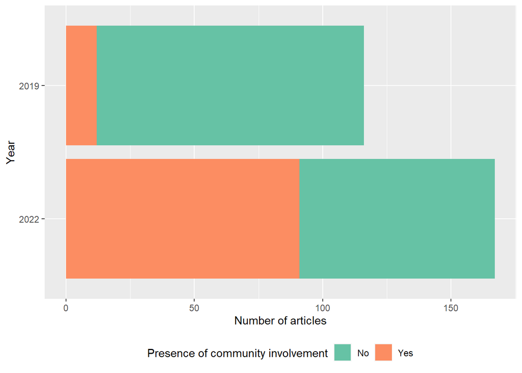

```r
yearCommInv <- fulldata %>%
  select("yearPub", "commInvPresence")

pubCountTotal <- yearCommInv %>%
  group_by(yearPub) %>%
  count()

pubByCommInv <- yearCommInv %>%
  group_by(yearPub) %>%
  filter(commInvPresence == "Yes") %>%
  count()

yearCommInv <- as.data.frame(table(yearCommInv))

freqBarChart <- ggplot(yearCommInv, aes(x = fct_relevel(yearPub, c("2022", "2019")), y = Freq, fill = fct_relevel(commInvPresence, c("No", "Yes")))) +
  geom_col() +
  labs(x = "Year",
       y = "Number of articles",
       fill = "Presence of community involvement") +
  scale_fill_brewer(palette = "Set2") +
  theme(legend.position = "bottom") +
  coord_flip()

freqBarChart
```

##### **2) Type of community involvement report**

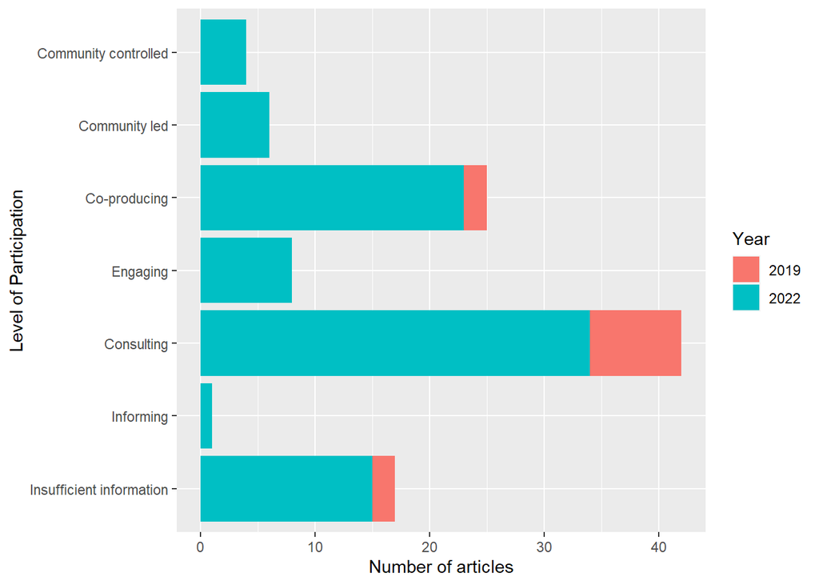

```r
partdata <- fulldata %>%
  filter(commInvPresence == "Yes") %>%
  select("levelOfPart", "yearPub")

partdata <- as.data.frame(table(partdata))

partBarChart <- ggplot(partdata, aes(fill = yearPub, x = fct_relevel(levelOfPart, c("Insufficient information", "Informing", "Consulting", "Engaging", "Co-producing", "Community led", "Community controlled")), y = Freq)) +
  geom_col(position = "stack") +
  labs(x = "Level of Participation",
       y = "Number of articles",
       fill = "Year") +
  coord_flip()

partBarChart
```

##### **3) Breadth of Community Involvement (OVERALL)**

Based on detailed coding scheme for the breadth of community involvement.

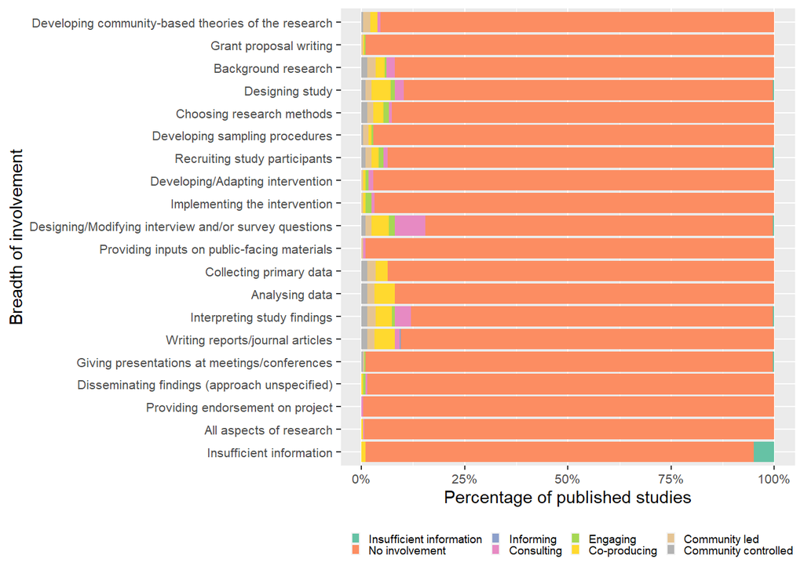

```r
breadthdata <- fulldata %>%
  select(PMID, c("Developing community-based theories of the research":"Insufficient information"))

#pivot wide to long

breadthdatalong <- breadthdata %>%
  pivot_longer(cols = c("Developing community-based theories of the research",
                        "Grant proposal writing",
                        "Background research",
                        "Designing study",
                        "Choosing research methods",
                        "Developing sampling procedures",
                        "Recruiting study participants",
                        "Developing/Adapting intervention",
                        "Implementing the intervention",
                        "Designing/Modifying interview and/or survey questions",
                        "Providing inputs on public-facing materials",
                        "Collecting primary data",
                        "Analysing data",
                        "Interpreting study findings",
                        "Writing reports/journal articles",
                        "Giving presentations at meetings/conferences",
                        "Disseminating findings (approach unspecified)",
                        "Providing endorsement on project",
                        "All aspects of research",
                        "Insufficient information"),
               names_to = "Breadth of Involvement",
               values_to = "Level of Participation")

#create cross table to calculate number of articles for each breadth of involvement  broken down by level of participation
breadthparttab <- crosstable(breadthdatalong, "Breadth of Involvement", by = "Level of Participation",
                percent_pattern = "{n}")
breadthparttab <- as.data.frame(breadthparttab)

breathpartlong <-  breadthparttab %>%
  pivot_longer(cols = c("No involvement", "Informing", "Consulting", "Engaging", "Co-producing", "Community led", "Community controlled", "Insufficient information"),
               names_to = "levelOfPart",
               values_to = "Count") %>%
  select(c("variable", "levelOfPart", "Count")) %>%
  rename("breadthOfPart" = "variable")

breathpartlong$Count <- as.numeric(breathpartlong$Count)

#create stacked percent bar chart
breadthBarChart <- ggplot(breathpartlong, aes(x = fct_relevel(breadthOfPart, c("Insufficient information", "All aspects of research", "Providing endorsement on project", "Disseminating findings (approach unspecified)", "Giving presentations at meetings/conferences", "Writing reports/journal articles", "Interpreting study findings", "Analysing data", "Collecting primary data", "Providing inputs on public-facing materials", "Designing/Modifying interview and/or survey questions", "Implementing the intervention", "Developing/Adapting intervention", "Recruiting study participants", "Developing sampling procedures", "Choosing research methods", "Designing study", "Background research", "Grant proposal writing", "Developing community-based theories of the research")), y = Count, fill = fct_relevel(levelOfPart, c("Insufficient information", "No involvement", "Informing", "Consulting", "Engaging", "Co-producing", "Community led", "Community controlled")))) +
  geom_bar(position = "fill", stat = "identity") +
  theme(legend.position = "bottom",
        legend.text = element_text(size = 7),
        legend.key.size = unit(.2, "cm"),
        axis.text.y = element_text(size = 8),
        axis.text.x = element_text(size = 8)) +
  labs(x = "Breadth of involvement",
       y = "Percentage of published studies",
       fill = "") +
  scale_y_continuous(labels = scales::percent) +
  scale_fill_brewer(palette = "Set2") +
  coord_flip()

breadthBarChart
```

##### **3a) Breadth of Community Involvement (2019)**

Based on detailed coding scheme for the breadth of community involvement.

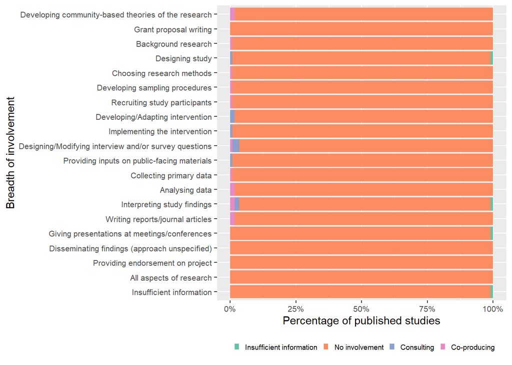

```r
breadthdata <- fulldata %>%
  filter(yearPub == 2019) %>%
  select(PMID, c("Developing community-based theories of the research":"Insufficient information"))

#pivot wide to long

breadthdatalong <- breadthdata %>%
  pivot_longer(cols = c("Developing community-based theories of the research",
                        "Grant proposal writing",
                        "Background research",
                        "Designing study",
                        "Choosing research methods",
                        "Developing sampling procedures",
                        "Recruiting study participants",
                        "Developing/Adapting intervention",
                        "Implementing the intervention",
                        "Designing/Modifying interview and/or survey questions",
                        "Providing inputs on public-facing materials",
                        "Collecting primary data",
                        "Analysing data",
                        "Interpreting study findings",
                        "Writing reports/journal articles",
                        "Giving presentations at meetings/conferences",
                        "Disseminating findings (approach unspecified)",
                        "Providing endorsement on project",
                        "All aspects of research",
                        "Insufficient information"),
               names_to = "Breadth of Involvement",
               values_to = "Level of Participation")

#create cross table to calculate number of articles for each breadth of involvement  broken down by level of participation
breadthparttab <- crosstable(breadthdatalong, "Breadth of Involvement", by = "Level of Participation",
                percent_pattern = "{n}")
breadthparttab <- as.data.frame(breadthparttab)

breathpartlong <-  breadthparttab %>%
  pivot_longer(cols = c("No involvement", "Consulting", "Co-producing", "Insufficient information"),
               names_to = "levelOfPart",
               values_to = "Count") %>%
  select(c("variable", "levelOfPart", "Count")) %>%
  rename("breadthOfPart" = "variable")

breathpartlong$Count <- as.numeric(breathpartlong$Count)

#create stacked percent bar chart
breadthBarChart <- ggplot(breathpartlong, aes(x = fct_relevel(breadthOfPart, c("Insufficient information", "All aspects of research", "Providing endorsement on project", "Disseminating findings (approach unspecified)", "Giving presentations at meetings/conferences", "Writing reports/journal articles", "Interpreting study findings", "Analysing data", "Collecting primary data", "Providing inputs on public-facing materials", "Designing/Modifying interview and/or survey questions", "Implementing the intervention", "Developing/Adapting intervention", "Recruiting study participants", "Developing sampling procedures", "Choosing research methods", "Designing study", "Background research", "Grant proposal writing", "Developing community-based theories of the research")), y = Count, fill = fct_relevel(levelOfPart, c("Insufficient information", "No involvement", "Consulting",  "Co-producing")))) +
  geom_bar(position = "fill", stat = "identity") +
  theme(legend.position = "bottom",
        legend.text = element_text(size = 7),
        legend.key.size = unit(.2, "cm"),
        axis.text.y = element_text(size = 8),
        axis.text.x = element_text(size = 8)) +
  labs(x = "Breadth of involvement",
       y = "Percentage of published studies",
       fill = "") +
  scale_y_continuous(labels = scales::percent) +
  scale_fill_brewer(palette = "Set2") +
  coord_flip()

breadthBarChart
```

##### **3b) Breadth of Community Involvement (2022)**

Based on detailed coding scheme for the breadth of community involvement.

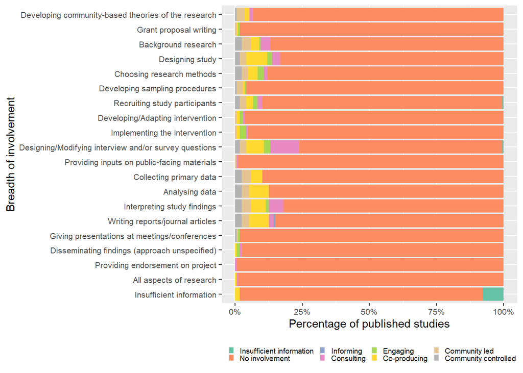

```r
breadthdata <- fulldata %>%
  filter(yearPub == 2022) %>%
  select(PMID, c("Developing community-based theories of the research":"Insufficient information"))

#pivot wide to long

breadthdatalong <- breadthdata %>%
  pivot_longer(cols = c("Developing community-based theories of the research",
                        "Grant proposal writing",
                        "Background research",
                        "Designing study",
                        "Choosing research methods",
                        "Developing sampling procedures",
                        "Recruiting study participants",
                        "Developing/Adapting intervention",
                        "Implementing the intervention",
                        "Designing/Modifying interview and/or survey questions",
                        "Providing inputs on public-facing materials",
                        "Collecting primary data",
                        "Analysing data",
                        "Interpreting study findings",
                        "Writing reports/journal articles",
                        "Giving presentations at meetings/conferences",
                        "Disseminating findings (approach unspecified)",
                        "Providing endorsement on project",
                        "All aspects of research",
                        "Insufficient information"),
               names_to = "Breadth of Involvement",
               values_to = "Level of Participation")

#create cross table to calculate number of articles for each breadth of involvement  broken down by level of participation
breadthparttab <- crosstable(breadthdatalong, "Breadth of Involvement", by = "Level of Participation",
                percent_pattern = "{n}")
breadthparttab <- as.data.frame(breadthparttab)

breathpartlong <-  breadthparttab %>%
  pivot_longer(cols = c("No involvement", "Informing", "Consulting", "Engaging", "Co-producing", "Community led", "Community controlled", "Insufficient information"),
               names_to = "levelOfPart",
               values_to = "Count") %>%
  select(c("variable", "levelOfPart", "Count")) %>%
  rename("breadthOfPart" = "variable")

breathpartlong$Count <- as.numeric(breathpartlong$Count)

#create stacked percent bar chart
breadthBarChart <- ggplot(breathpartlong, aes(x = fct_relevel(breadthOfPart, c("Insufficient information", "All aspects of research", "Providing endorsement on project", "Disseminating findings (approach unspecified)", "Giving presentations at meetings/conferences", "Writing reports/journal articles", "Interpreting study findings", "Analysing data", "Collecting primary data", "Providing inputs on public-facing materials", "Designing/Modifying interview and/or survey questions", "Implementing the intervention", "Developing/Adapting intervention", "Recruiting study participants", "Developing sampling procedures", "Choosing research methods", "Designing study", "Background research", "Grant proposal writing", "Developing community-based theories of the research")), y = Count, fill = fct_relevel(levelOfPart, c("Insufficient information", "No involvement", "Informing", "Consulting", "Engaging", "Co-producing", "Community led", "Community controlled")))) +
  geom_bar(position = "fill", stat = "identity") +
  theme(legend.position = "bottom",
        legend.text = element_text(size = 7),
        legend.key.size = unit(.2, "cm"),
        axis.text.y = element_text(size = 8),
        axis.text.x = element_text(size = 8)) +
  labs(x = "Breadth of involvement",
       y = "Percentage of published studies",
       fill = "") +
  scale_y_continuous(labels = scales::percent) +
  scale_fill_brewer(palette = "Set2") +
  coord_flip()

breadthBarChart
```

##### **4) Breadth of Community Involvement (OVERALL)**

Based on broad coding scheme for the breadth of community involvement.

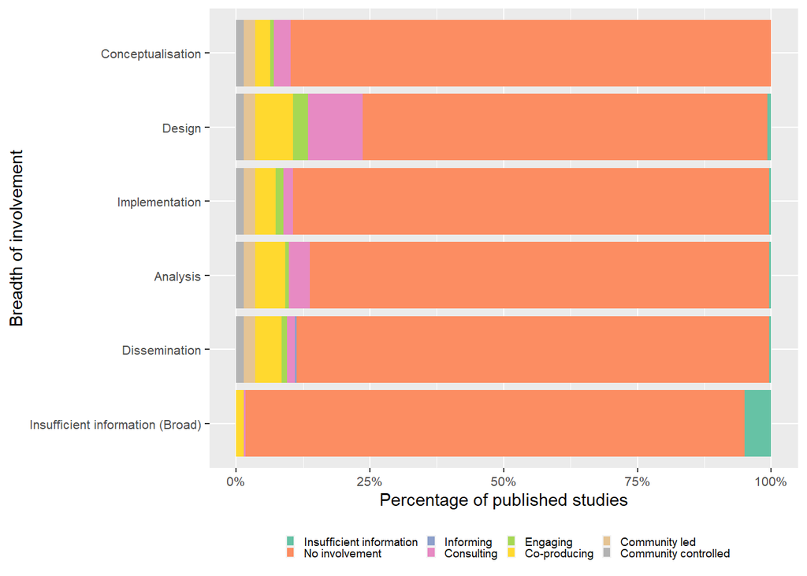

```r
breadthbroaddata <- fulldata %>%
  select(PMID, c("Conceptualisation":"Insufficient information (Broad)"))

#pivot wide to long

breadthbroadlong <- breadthbroaddata %>%
  pivot_longer(cols = c("Conceptualisation",
                        "Design",
                        "Implementation",
                        "Analysis",
                        "Dissemination",
                        "Insufficient information (Broad)"),
               names_to = "Breadth of Involvement",
               values_to = "Level of Participation")

#create cross table to calculate number of articles for each breadth of involvement  broken down by level of participation
breadthbroadtab <- crosstable(breadthbroadlong, "Breadth of Involvement", by = "Level of Participation",
                percent_pattern = "{n}")
breadthbroadtab <- as.data.frame(breadthbroadtab)

breathbroadtablong <-  breadthbroadtab %>%
  pivot_longer(cols = c("No involvement", "Informing", "Consulting", "Engaging", "Co-producing", "Community led", "Community controlled", "Insufficient information"),
               names_to = "levelOfPart",
               values_to = "Count") %>%
  select(c("variable", "levelOfPart", "Count")) %>%
  rename("breadthOfPart" = "variable")

breathbroadtablong$Count <- as.numeric(breathbroadtablong$Count)

#create stacked percent bar chart
breadthBroadBarChart <- ggplot(breathbroadtablong, aes(x = fct_relevel(breadthOfPart,c("Insufficient information (Broad)", "Dissemination", "Analysis", "Implementation", "Design", "Conceptualisation")), y = Count, fill = fct_relevel(levelOfPart, c("Insufficient information", "No involvement", "Informing", "Consulting", "Engaging", "Co-producing", "Community led", "Community controlled")))) +
  geom_bar(position = "fill", stat = "identity") +
  theme(legend.position = "bottom",
        legend.text = element_text(size = 7),
        legend.key.size = unit(.2, "cm"),
        axis.text.y = element_text(size = 8),
        axis.text.x = element_text(size = 8)) +
  labs(x = "Breadth of involvement",
       y = "Percentage of published studies",
       fill = "") +
  scale_y_continuous(labels = scales::percent) +
  scale_fill_brewer(palette = "Set2") +
  coord_flip()

breadthBroadBarChart
```

##### **4a) Breadth of Community Involvement (2019)**

Based on broad coding scheme for the breadth of community involvement for 2019 papers.

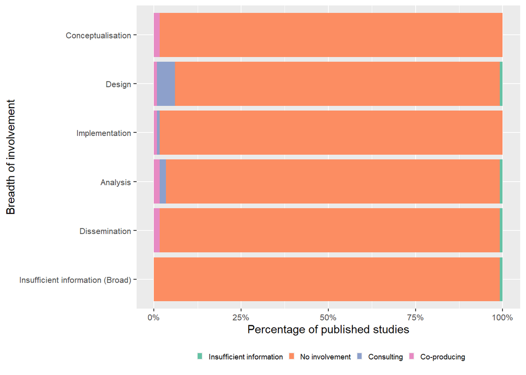

```r
breadthbroaddata <- fulldata %>%
  filter(yearPub == 2019) %>%
  select(PMID, c("Conceptualisation":"Insufficient information (Broad)"))

#pivot wide to long

breadthbroadlong <- breadthbroaddata %>%
  pivot_longer(cols = c("Conceptualisation",
                        "Design",
                        "Implementation",
                        "Analysis",
                        "Dissemination",
                        "Insufficient information (Broad)"),
               names_to = "Breadth of Involvement",
               values_to = "Level of Participation")

#create cross table to calculate number of articles for each breadth of involvement  broken down by level of participation
breadthbroadtab <- crosstable(breadthbroadlong, "Breadth of Involvement", by = "Level of Participation",
                percent_pattern = "{n}")
breadthbroadtab <- as.data.frame(breadthbroadtab)

breathbroadtablong <-  breadthbroadtab %>%
  pivot_longer(cols = c("No involvement", "Consulting", "Co-producing", "Insufficient information"),
               names_to = "levelOfPart",
               values_to = "Count") %>%
  select(c("variable", "levelOfPart", "Count")) %>%
  rename("breadthOfPart" = "variable")

breathbroadtablong$Count <- as.numeric(breathbroadtablong$Count)

#create stacked percent bar chart
breadthBroadBarChart <- ggplot(breathbroadtablong, aes(x = fct_relevel(breadthOfPart,c("Insufficient information (Broad)", "Dissemination", "Analysis", "Implementation", "Design", "Conceptualisation")), y = Count, fill = fct_relevel(levelOfPart, c("Insufficient information", "No involvement", "Informing", "Consulting", "Engaging", "Co-producing", "Community led", "Community controlled")))) +
  geom_bar(position = "fill", stat = "identity") +
  theme(legend.position = "bottom",
        legend.text = element_text(size = 7),
        legend.key.size = unit(.2, "cm"),
        axis.text.y = element_text(size = 8),
        axis.text.x = element_text(size = 8)) +
  labs(x = "Breadth of involvement",
       y = "Percentage of published studies",
       fill = "") +
  scale_y_continuous(labels = scales::percent) +
  scale_fill_brewer(palette = "Set2") +
  coord_flip()

breadthBroadBarChart
```

##### **4b) Breadth of Community Involvement (2022)**

Based on broad coding scheme for the breadth of community involvement for 2022 papers.

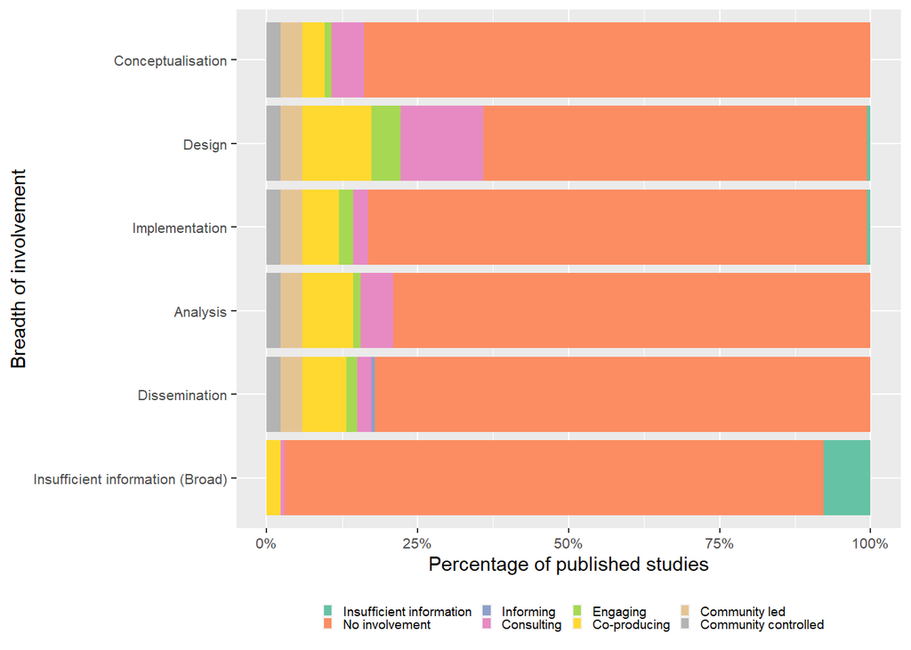

```r
breadthbroaddata <- fulldata %>%
  filter(yearPub == 2022) %>%
  select(PMID, c("Conceptualisation":"Insufficient information (Broad)"))

#pivot wide to long

breadthbroadlong <- breadthbroaddata %>%
  pivot_longer(cols = c("Conceptualisation",
                        "Design",
                        "Implementation",
                        "Analysis",
                        "Dissemination",
                        "Insufficient information (Broad)"),
               names_to = "Breadth of Involvement",
               values_to = "Level of Participation")

#create cross table to calculate number of articles for each breadth of involvement  broken down by level of participation
breadthbroadtab <- crosstable(breadthbroadlong, "Breadth of Involvement", by = "Level of Participation",
                percent_pattern = "{n}")
breadthbroadtab <- as.data.frame(breadthbroadtab)

breathbroadtablong <-  breadthbroadtab %>%
  pivot_longer(cols = c("No involvement", "Informing", "Consulting", "Engaging", "Co-producing", "Community led", "Community controlled", "Insufficient information"),
               names_to = "levelOfPart",
               values_to = "Count") %>%
  select(c("variable", "levelOfPart", "Count")) %>%
  rename("breadthOfPart" = "variable")

breathbroadtablong$Count <- as.numeric(breathbroadtablong$Count)

#create stacked percent bar chart
breadthBroadBarChart <- ggplot(breathbroadtablong, aes(x = fct_relevel(breadthOfPart,c("Insufficient information (Broad)", "Dissemination", "Analysis", "Implementation", "Design", "Conceptualisation")), y = Count, fill = fct_relevel(levelOfPart, c("Insufficient information", "No involvement", "Informing", "Consulting", "Engaging", "Co-producing", "Community led", "Community controlled")))) +
  geom_bar(position = "fill", stat = "identity") +
  theme(legend.position = "bottom",
        legend.text = element_text(size = 7),
        legend.key.size = unit(.2, "cm"),
        axis.text.y = element_text(size = 8),
        axis.text.x = element_text(size = 8)) +
  labs(x = "Breadth of involvement",
       y = "Percentage of published studies",
       fill = "") +
  scale_y_continuous(labels = scales::percent) +
  scale_fill_brewer(palette = "Set2") +
  coord_flip()

breadthBroadBarChart
```